# STAT 240 Discussion 8 Solutions

## Members Absent

*Make sure to set aside at least half of discussion time for working on the project proposal!*

## Questions

### 1

If $X \sim \text{N}(20, 3)$, what is $\mathsf{P}(15 < X < 27)$?

> SOLUTION

```r
pnorm(27, 20, 3) - pnorm(15, 20, 3)
```

```
## [1] 0.9423943
```

### 2

Draw a graph of a normal distribution with mean 20 and standard deviation 3 with the area between 15 and 27 shaded. How does this area correspond to the previous calculated probability?

> SOLUTION

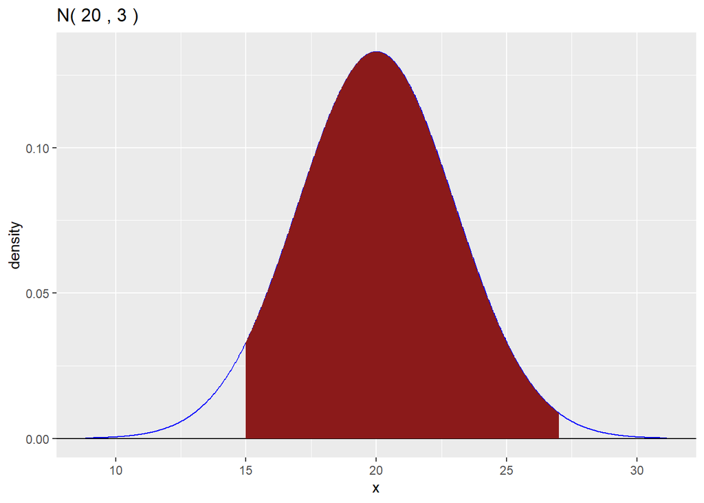

```r
gnorm(20, 3) +
  geom_norm_fill(20, 3, a = 15, b = 27)
```

The shaded area equals the previous problem calculation.

### 3

Define $z_1 = (15 - 20)/3$ and $z_2 = (27 - 20)/3$. If $Z \sim \text{N}(0,1)$, what is $\mathsf{P}(z_1 < Z < z_2)$?

> SOLUTION

```r
x1 = 15
x2 = 27
mu = 20
sigma = 3
z1 = (x1 - mu)/sigma
z2 = (x2 - mu)/sigma

## Calculation
pnorm(z2) - pnorm(z1)
```

```
## [1] 0.9423943
```

### 4

Draw a graph of a standard normal distribution and shade the area under the curve between $z_1$ and $z_2$ from the previous problem. How does this plotted graph compare to the graph made in question 2?

> SOLUTION

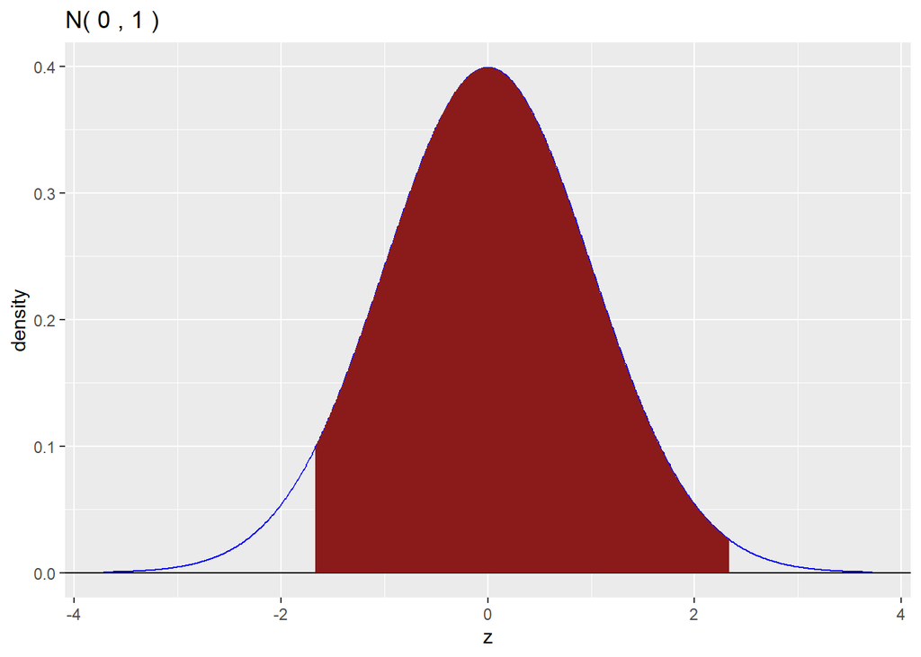

```r
gnorm() +
  geom_norm_fill(a = z1, b = z2) +
  xlab("z")
```

The graph is identical except for the scaling of the axes.

### Project proposal

Now, use the rest of your time to work on the project proposal in your groups. Come up with an appropriate dataset, a question to ask, and some ideas of how to proceed. Write this all up in a 1-page document according to the project description page on canvas and make sure to submit by the deadline.